# Wine Prediction

FRANCIS JINGO

May-10-2021

# HarvardX: Data Science: Capstone

## Introduction

Wine is a drink consumed at large scale by majority of the global population (https://wineinstitute.org). The makers must be able to ensure quality of their production, otherwise the demand for the particular brand will go down as well as the market share. Based on this, most wine manufacturers have resorted to discovering ways to improve the quality and this has led to most of them using machine learning. The aim is to determine the quality of the product based on the ingredients used during the manufacturing process.We are going to use two types of wine that is red wine and white wine.

The ingredients used in this notebook include: `['wine_type','fixed acidity', 'volatile acidity', 'citric acid', 'residual sugar', 'chlorides', 'free sulfur dioxide', 'total sulfur dioxide', 'density', 'pH', 'sulphates', 'alcohol']` and these are considered the predictor features. The output feature is ‘quality’.

## Methods

In this section, I talk about the methods used in this project.

### Test accuracy

This is used to test the accuracy of our prediction, we look at the values that are exactly the same as in the model, and consider those a success, otherwise our prediction is false, this ensures out accuracy is as factual as possible.

```r
test_accuracy <- function(pred,actual)
{
  val<-(actual - pred)
  len<-length(which(val==0))
  len/length(pred)
}
```

### Add Elements

This is used to add elements from one list to another list where items in list2 are added to list1.

```r
addElements <- function(list1,list2){
  len1 <- length(list1)
  i <- len1+1
  a<-1
  len2 <- length(list2)
  while(a <= len2){
    list1[i] <- list2[a]
    a <-a+1
    i<-i+1
  }
  list1
}
```

### Find Outliers

This is used to determine which values in the dataset are considered outliers based on median and standard deviation where dt is the whole dataframe and col is the column with the outliers.

```r
FindOutliers <- function(dt,col){
    sd <- as.numeric(sapply(dt[col],sd))
    med <- as.numeric(sapply(dt[col],median))
    lowerq <- med - (sd*3)
    upperq <- med + (sd*3)
    which(dt[col]>upperq | dt[col]<lowerq)
}
```

### Data exploration and visualization

The datset is explored to have an understanding of some of its elements. Below are the top rows in the dataset.

```r
head(wine_data)
```

| wine_type | fixed_acidity | volatile_acidity | citric_acid | residual_sugar | chlorides | free_sulfurdioxide | total_sulfurdioxide | density | pH | sulphates | alcohol | quality |
| --- | --- | --- | --- | --- | --- | --- | --- | --- | --- | --- | --- | --- |
| Red | 5.4 | 0.74 | 0.00 | 1.20 | 0.041 | 16 | 46 | 0.99258 | 4.01 | 0.59 | 12.5 | 6 |
| Red | 5.0 | 0.74 | 0.00 | 1.20 | 0.041 | 16 | 46 | 0.99258 | 4.01 | 0.59 | 12.5 | 6 |
| Red | 5.1 | 0.47 | 0.02 | 1.30 | 0.034 | 18 | 44 | 0.99210 | 3.90 | 0.62 | 12.8 | 6 |
| Red | 4.6 | 0.52 | 0.15 | 2.10 | 0.054 | 8 | 65 | 0.99340 | 3.90 | 0.56 | 13.1 | 4 |
| Red | 4.7 | 0.60 | 0.17 | 2.30 | 0.058 | 17 | 106 | 0.99320 | 3.85 | 0.60 | 12.9 | 6 |
| White | 5.3 | 0.26 | 0.23 | 5.15 | 0.034 | 48 | 160 | 0.99520 | 3.82 | 0.51 | 10.5 | 7 |

Next we look at the structure of the dataset since we have two wine types, it is better to dig into both of them to understand the dataset better. We start with the information to know how many null values we have as well as the data types.

```r
colSums(is.na(wine_data))
```

```
##           wine_type       fixed_acidity    volatile_acidity         citric_acid
##                   0                   0                   0                   0
##      residual_sugar           chlorides  free_sulfurdioxide total_sulfurdioxide
##                   0                   0                   0                   0
##             density                  pH           sulphates             alcohol
##                   0                   0                   0                   0
##             quality
##                   0
```

Next we look at the shapes of the entire wine dataset. We then look at the white wine data and the red wine data contained in the dataset.

```r
dim(wine_data)
```

```
## [1] 6497   13
```

```r
red_wine <- wine_data %>% filter(wine_type=='Red') %>% select(-wine_type)
dim(red_wine)
```

```
## [1] 1599   12
```

```r
white_wine <- wine_data %>% filter(wine_type=='White') %>% select(-wine_type)
dim(white_wine)
```

```
## [1] 4898   12
```

Looking at the quality summary for the datasets.

```r
summary(wine_data$quality)
```

```
##    Min. 1st Qu.  Median    Mean 3rd Qu.    Max.
##   3.000   5.000   6.000   5.818   6.000   9.000
```

```r
summary(red_wine$quality)
```

```
##    Min. 1st Qu.  Median    Mean 3rd Qu.    Max.
##   3.000   5.000   6.000   5.636   6.000   8.000
```

```r
summary(white_wine$quality)
```

```
##    Min. 1st Qu.  Median    Mean 3rd Qu.    Max.
##   3.000   5.000   6.000   5.878   6.000   9.000
```

Plotting the distribution count of the wine dataset to see the counts between the white wine and the red wine.

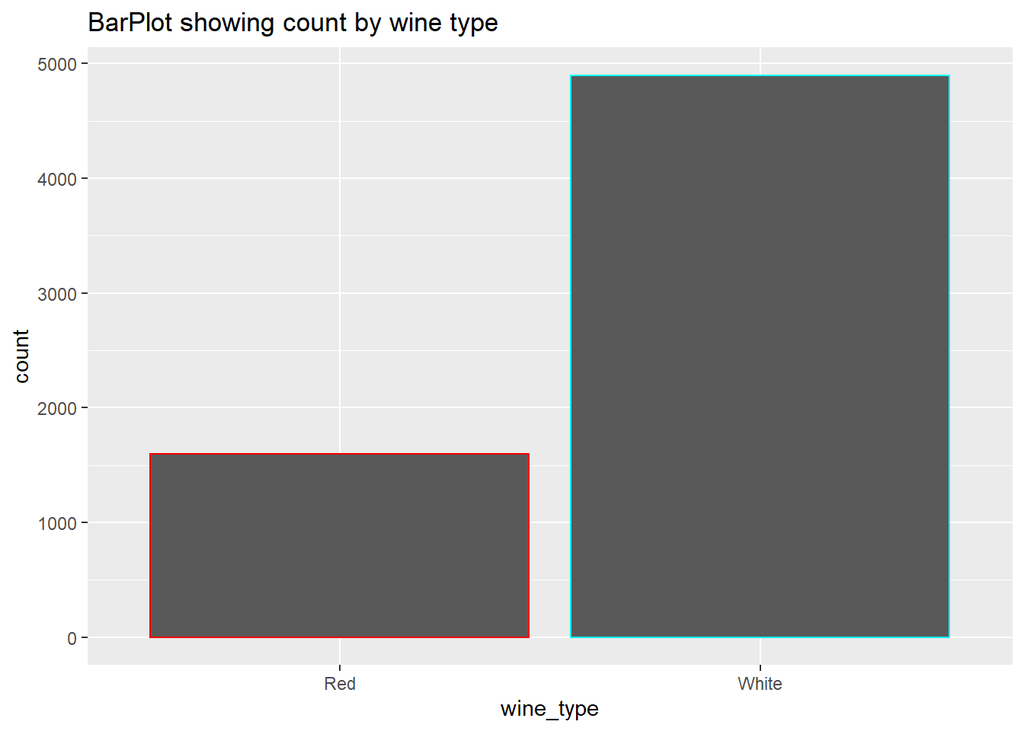

From the above, we can see that the white wine dataset has more rows meaning it has more observations. We also see that the data has no null values and has 12 predictor columns and one dependent column. Further, we can tell that all predictor columns are numerical except for wine type, to make this numerical, we shall have to create two categorical features having 1 or 0, one for red wine, another for white wine. We can also see that no column is categorical except for the two we create below.

Next, we look at the dependent column to determine the nature of the values in the column. From the below, we can tell that it is an integer rank ranging from 0 of 10.

```r
unique(wine_data$quality)
```

```
## [1] 6 4 7 5 8 3 9
```

We now look at correlation, we could print out the `correlation matrix` of the columns however i think using a `heatmap` might be prefferable since it is easier to spot very highly correlated and very lowly correlated columns than on the matrix, lets have a look.

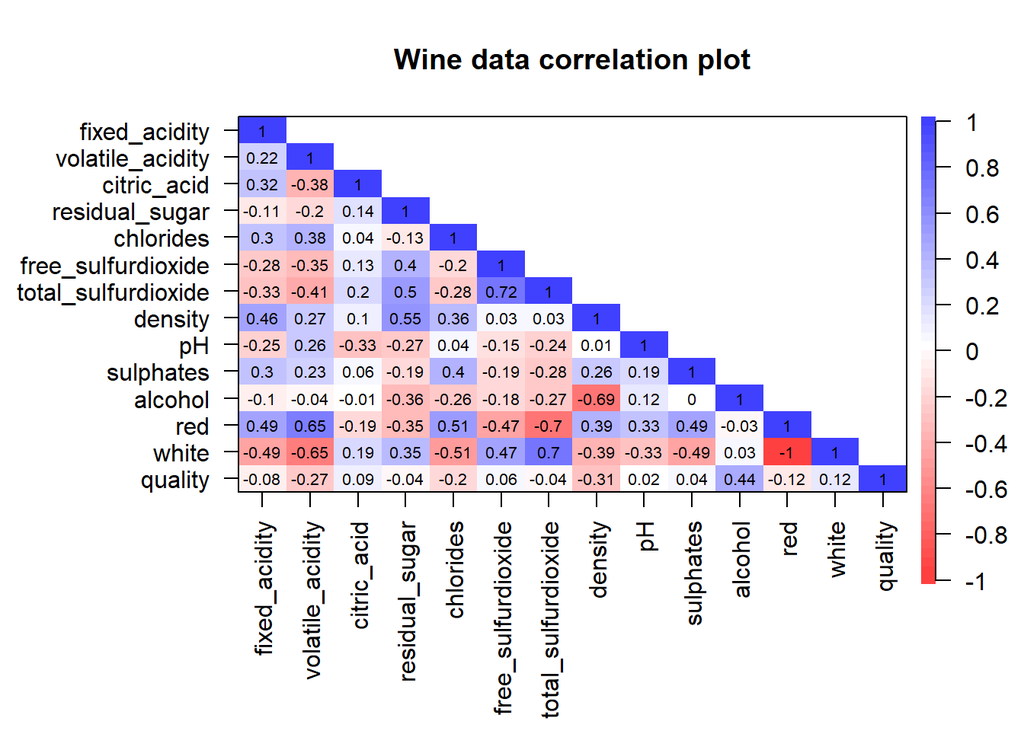

```r
corPlot(wine_data,scale=FALSE,xlas=2,upper=FALSE,main='Wine data correlation plot')
```

We then calculate the average of each feature for the red and white wines separately using mean() function and plot bar graph to show comparison. This will help us understand the basic average between the quantities of ingredients used for the two different wine datasets. From below we can see that most features have an almost similar mean 2 for the two datasets except for free sulfurdioxide and total sulfur dioxide which have a significant difference between the two means. We can also plot these to have a visualization.

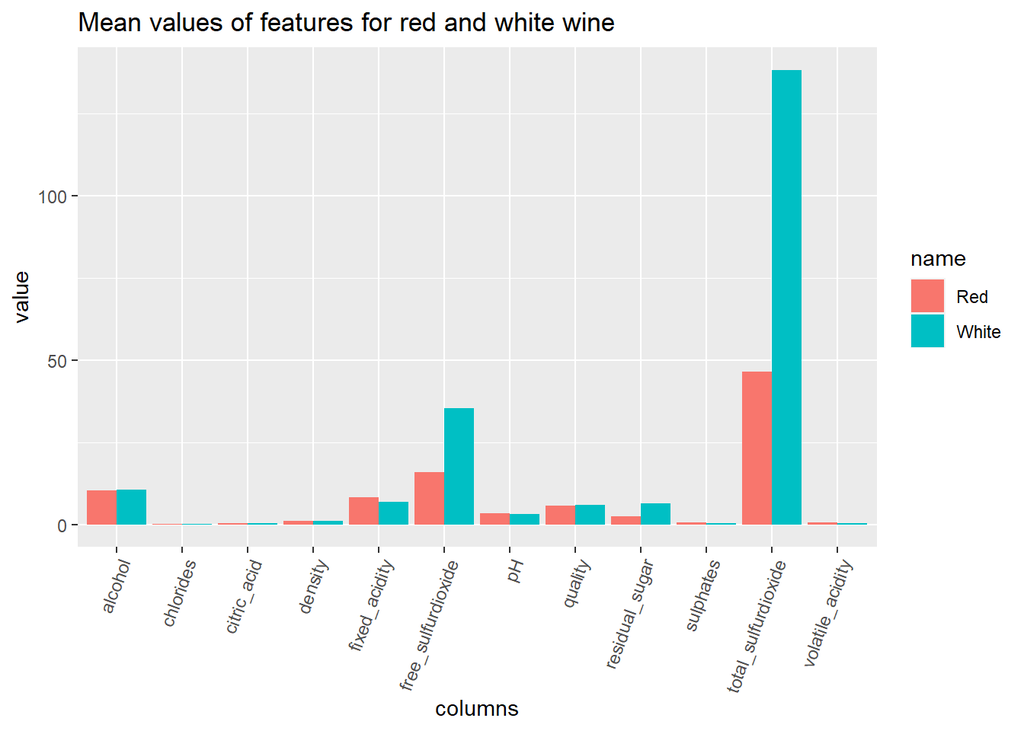

```r
red_means <- red_wine %>% colMeans()
white_means <- white_wine %>% colMeans()
wine_data2 <- wine_data %>% select(-red,-white)

wine_means <- structure(list(columns = c(colnames(wine_data2)),
                White = c(white_means),Red = c(red_means)),
                 class = "data.frame",
                 row.names = c('1','2','3','4','5','6','7','8','9','10','11', '12'))

wine_means %>%
  pivot_longer(cols = -columns) %>%
  ggplot(aes(x = columns, y = value, fill = name)) +
  geom_col(position = 'dodge')+
  theme(axis.text.x = element_text(angle = 70, hjust = 1))+
  ggtitle('Mean values of features for red and white wine')
```

## Outliers

These are biased observations that may make our data analysis inaccurate. They are 3 standard deviations away from the median. We can perform a box plot to check if there are any outliers.

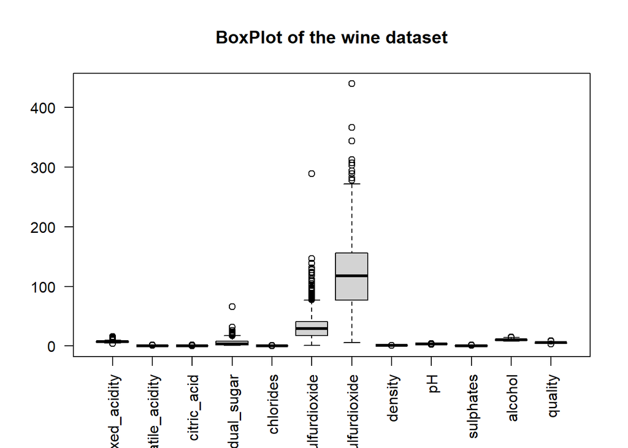

We can also have the outliers count in a data frame to correctly see how many outliers each column has. From the below we can see that 8 columns have less than 100 rows with outliers.

```r
cols <- c(colnames(wine_data2))
outlier_data <- data.frame(columns = cols)
outlier_count <- c()
outlier_indexes <- c()
i <-1
for(col in cols) {
  lis <- FindOutliers(wine_data2,col)
  outlier_indexes <- addElements(outlier_indexes, c(lis))
  outlier_count[i] <- length(lis)
  i <- i+1
}
outlier_indexes <- unique(outlier_indexes)
outlier_data <- outlier_data %>% mutate(outliers = outlier_count)
outlier_data
```

| columns | outliers |
| --- | --- |
| fixed_acidity | 148 |
| volatile_acidity | 128 |
| citric_acid | 29 |
| residual_sugar | 145 |
| chlorides | 122 |
| free_sulfurdioxide | 41 |
| total_sulfurdioxide | 8 |
| density | 3 |
| pH | 35 |
| sulphates | 88 |

[output cut: 2 more lines]